# How Does Competition Affect Productivity in New Zealand?

Honours Research Meeting

Benjamin Stubbing

September 4, 2025

## What I’m doing, why it matters & what I’ll talk about today

- **Productivity is one of the biggest long-run determinants of living standards**: NZ faces a secular productivity challenge, so it’s valuable to learn how much of the variance in productivity is attributable to (lack of) competition
- **Previous work was limited** by data variation and analysis was associative
- I’m using a **longer time series** and trying to identify **causal inference**

No results to summarise at this point; instead, I’m going to talk about:

1. **data prep**: how I used the LBD to measure competition and productivity
2. **methods** & where identification is coming from

# 1. Data Prep

## To estimate competition’s productivity effects, we need variables for competition and productivity

Using the Longitudinal Business Database (**LBD**), which provides administrative firm-level data…

1. **Competition is estimated by Herfindahl-Hirshman index**
2. **Productivity is estimated by Total Factor Productivity (TFP)**

Competition details

## We measure productivity as TFP: that which is not explained by observables

$$\text{Gross Output} = f(\text{Capital}, \text{Labour}, \text{Intermediates}) \times \text{TFP}$$

- **Intuition**: TFP is efficiency in turning inputs into outputs
- TFP $=$ firm FE + time-varying residual
  - Fixed effects absorb industry-year shocks and capture persistent firm productivity
- *N.b.*, revenue-based TFP $\neq$ pure technology, it also reflects demand & markup shocks (Klette–Griliches critique)

Show me the real math

## To get TFP, we create production functions using LBD admin data

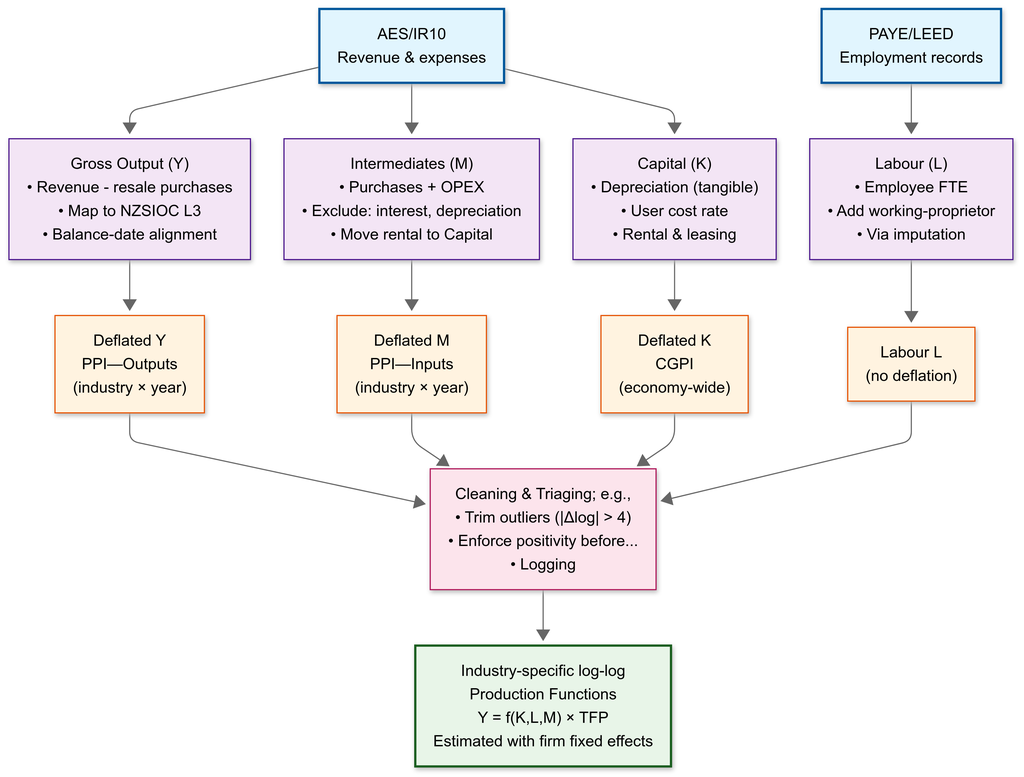

Data-prep

# 2. Methods & Identification

## Why is competition associated with productivity?

### 1. Treatment Effect

Competition **directly affect** on productivity, *induceing* firms to adopt some characteristics commensurate with productivity (*e.g.*, R&D, managerial talent)

### 2. Selection Effect

Competition leads to **selective attrition** of low-productivity firms: More-efficient firms accumulate market share, forcing the exit of less-efficient firms

To disentangle the two effects, I’m adapting 2 methods from Backus<sup>1</sup>:

1. Olley-Pakes decomposition
2. Quantile-regression
[^1]: Backus, M. (2020), Why Is Productivity Correlated With Competition?. Econometrica, 88: 2415-2444. https://doi.org/10.3982/ECTA12926

## How do we identify competition’s productivity effects?

| Source of endogeneity | Mitigation |
| --- | --- |
| **Reverse causality** (simultaneity) | IV: demand shifters (strong first stage) |
| **Omitted variables** | Firm FE + market trends; IV (demand/policy shocks) |
| **Measurement confounds** (TFPR) | Careful deflators; note TFPR ≠ pure technology |

- A demand shifter is a factor that predicts consumer demand without directly changing firms’ production technology
- Relevance: demand shifter $\implies$ market size/composition $\rightarrow$ entry/exit & share reallocation $\rightarrow$ HHI moves mechanically
- Validity: After deflation and FE, demand shifter affects TFPR only via competition

Two stage model

## Did the Good Firms Get Bigger, or Did the Average Firm Just Get Less Bad (or Die)?

Olley-Pakes decomposition splits market-level productivity into unweighted mean & covariance term that captures *reallocation across survivors*:

- If market shares reshuffle toward high-TFP among survivors $\rightarrow$ intensive (OP covariance)
- If the set of plants itself improve $\rightarrow$ extensive (unweighted mean), but could move for two reasons:
  1. within-plant **treatment**
  2. **selection** (because the cross-section you average over changed)

OP shows us *upon which margin competition affects productivity*, but within the mean it **cannot** separate treatment from selection

## Does Competition Kill Losers or Make Everyone Less Mediocre?

- If competition mainly bites by *truncating the left tail* $\implies$ effect of competition should be much larger at low quantiles of the productivity distribution than at the median/right tail
- We can see how the effect of competition varies across the distribution by **regressing productivity quantile** (within each industry/market–year) **on competition** IV

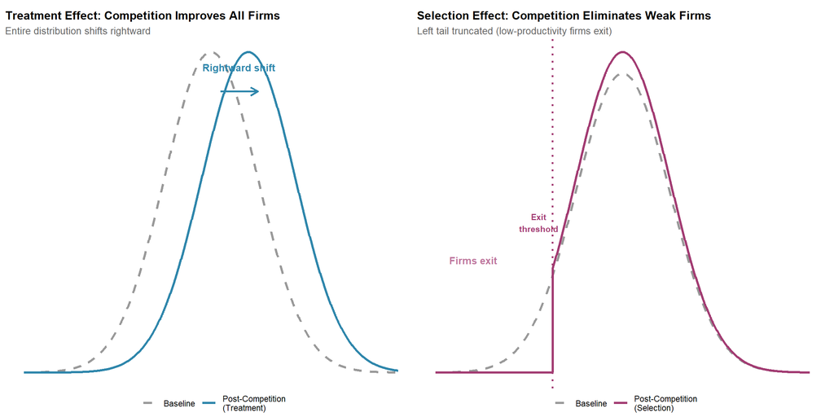

## Problem: competition is mechanically correlated with productivity quantiles

[output not shown]

**Key insight:** “Same” quantiles are different order statistics!

- Small markets: quantiles $=$ extremes (min/max)
- Large markets: quantiles $\neq$ extremes

**Bias:** Larger $n$ $\rightarrow$ more extreme minimums $\rightarrow$ “10th percentile” looks mechanically worse

- Competition effect estimates are **contaminated by sample size effects**
- Left tail biased downward, right tail biased upward

**Solution:** Add polynomial in $n$ to purge mechanical dependence

## What are your questions?

Thanks to **Yiğit Sağlam** for his supervision, Tim Ng for his support, Mathew Backus for his paper, and to Richard Fabling and Dave Maré pioneering work and balanced panels.

All mistakes, regrettably, are my own.

# Appendix

## I estimate the following for each industry $j$…

$$\ln y_{itj}
= \beta^{(j)}_K \ln K_{itj}
+ \beta^{(j)}_L \ln L_{itj}
+ \beta^{(j)}_M \ln M_{itj}
+ \tau^{(j)}_t + \mu^{(j)}_i + \varepsilon_{itj}.$$

- **Interpretation:** within industry $j$, **TFP** is the firm component captured by **$\mu_i$ + residual** $\varepsilon_{itj}$
- **Fixed effects:** include **year FE** $(\tau^{(j)}_t)$ and **firm FE** $(\mu^{(j)}_i)$
- **Industry handling:** estimate **separately by industry** so $(\beta^{(j)}_{\cdot})$ are industry-specific; **don’t** compare MFP levels across industries.

Back to stylised model

## What’s a demand shifter IV?

**Two-stage model:**

$$\begin{align}
X &= \pi Z + \Gamma W + v \quad \text{(first stage)} \\
Y &= \beta X + \delta' W + u \quad \text{(second stage)}
\end{align}$$

**Relevance:** $\pi \neq 0$.

**Exclusion:** $Z \perp u$ and no path $Z \to Y$ except through $X$.

Back to identification

## Olley-Pakes eq.

$$p_{mt} = \underbrace{\bar{\omega}_{mt}}_{\text{unweighted mean}} + \underbrace{\text{cov}_{mt}(s_i, \omega_i)}_{\text{OP "reallocation" term}}$$

## Quantile regression eq.

Backus writes the grouped-quantile IV model for the $k$-th decile $\rho_{mt}^{(k)}$:

$$\rho_{mt}^{(k)} = \beta_i^{(k)} + \beta_c^{(k)} c_{mt} + \nu_{mt}.$$
With teh polynomial fix:

$$p_{mt}^{(k)} = \beta_i^{(k)} + \beta_c^{(k)} c_{mt} + g^{(k)}(n_{mt}) + \nu_{mt},$$

## Competition estimated using market concentration & power measures

| Type | Measure | Description |
| --- | --- | --- |
| Structure | **HHI** | Weighted measure of market concentration *Larger ⇒ weaker competition* |
| Power | **PCM** | Percentage markup over costs *Higher ⇒ weaker competition* |
| Power | **PE** | How strongly cost increases reduce profits (negative values) *Smaller negative ⇒ weaker competition* (profits less sensitive to costs) *Larger negative ⇒ stronger competition* (profits more sensitive) |

Back to main slides

## Herfindahl-Hirschman Index (HHI)

$$\text{HHI}_{X,jt} = \frac{\sum_{i=1}^{N_jt} X_{ijt}^2}{(\sum_{i=1}^{N_jt} X_{ijt})^2}, X \in \{Y, L\}$$

- Captures how unequally market shares are distributed
- Higher HHI indicates greater concentration
- Lower HHI indicates more evenly distributed market share
- Can be calculated using labour or output
- $\text{HHI}_{X,jt} \in (0,1]$

Back to four competition metrics

## Price-Cost Margin (PCM)

**Average PCM**
$$\text{PCM}_{jt} = \frac{1}{N_{jt}}\sum_{i=1}^{N_{jt}}\max\left\{\frac{Y_{ijt} - C_{ijt}}{Y_{ijt}}, -1\right\}$$

- Average profit margin across industry, giving equal weight to each firm regardless of size
- Lower bound of $-1$ to avoid small firms skewing results; *i.e.*, $\text{PCM}_{jt} \in [-1, 1)$

**Aggregate PCM**
$$\text{PCM}_{A,jt} = \frac{\sum_{i=1}^{N_{jt}}(Y_{ijt} - C_{ijt})}{\sum_{i=1}^{N_{jt}} Y_{ijt}}$$

- Industry-wide profit margin, weighting each firm by its output
- Ratio of total industry profits to total industry outputs
- $\text{PCM}_{A,jt} \in (-\infty, 1)$

Back to four competition metrics

## Profit Elasticity (PE)

$$\ln(Y_{ijt} - C_{ijt}) = \alpha_{j't} + \text{PE}_{jt} \times \frac{C_{ijt}}{Y_{ijt}} + \epsilon_{ijt}$$

Back to four competition metrics

[^2]: *N.b.* the elasticity estimated here is already a negative number, whereas it is standard to express elasticities as $\varepsilon = -\frac{\frac{dx}{x}}{\frac{dp}{p}} = -\frac{p\,dx}{x\,dp} = -\frac{px'(p)}{x(p)}$ and $\epsilon \in [0,\infty)$